# ResultTemplate

Loong Kuan

17 September 2016

## Original Data of 2 Dates

Load data.

Data from before “drift”.

```
##   date day   period nswprice nswdemand vicprice vicdemand transfer class
## 1    0   2 0.000000 0.056443  0.439155 0.003467  0.422915 0.414912    UP
## 2    0   2 0.021277 0.051699  0.415055 0.003467  0.422915 0.414912    UP
## 3    0   2 0.042553 0.051489  0.385004 0.003467  0.422915 0.414912    UP
## 4    0   2 0.063830 0.045485  0.314639 0.003467  0.422915 0.414912    UP
## 5    0   2 0.085106 0.042482  0.251116 0.003467  0.422915 0.414912  DOWN
```

Data from after “drfit”.

```
##           date day   period nswprice nswdemand vicprice vicdemand transfer
## 22657 0.456351   5 0.000000 0.035487  0.544630 0.002349  0.490161 0.663158
## 22658 0.456351   5 0.021277 0.034436  0.528265 0.002248  0.467374 0.687719
## 22659 0.456351   5 0.042553 0.034856  0.496727 0.002302  0.518643 0.580263
## 22660 0.456351   5 0.063830 0.034226  0.447783 0.002289  0.498964 0.637281
## 22661 0.456351   5 0.085106 0.034016  0.387533 0.002202  0.452097 0.665789
##       class
## 22657    UP
## 22658  DOWN
## 22659  DOWN
## 22660  DOWN
## 22661  DOWN
```

Histogram of the data by attributes.

```
## [1] "Plots Obtained"
```

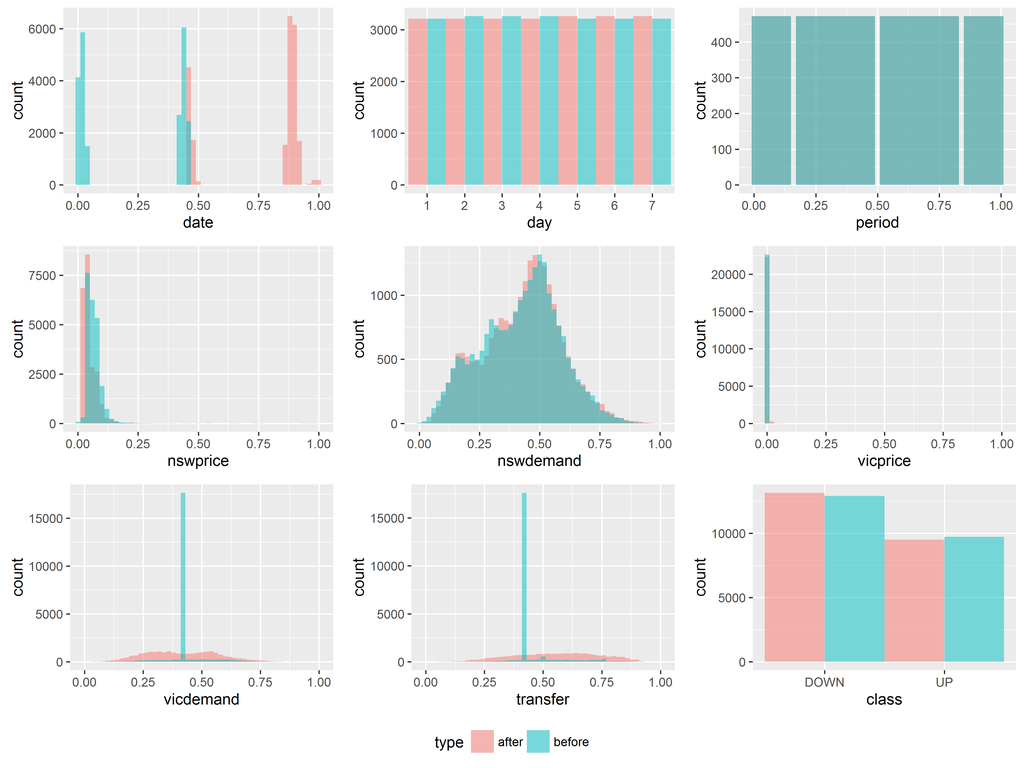

## Drift Results

The raw data of the results will be provided at the end of this document.

### Covariate Drift

The following is the results for a test of 1 Attribute. We can verify the correctness of the results by comparing them to the histograms of the attributes above.

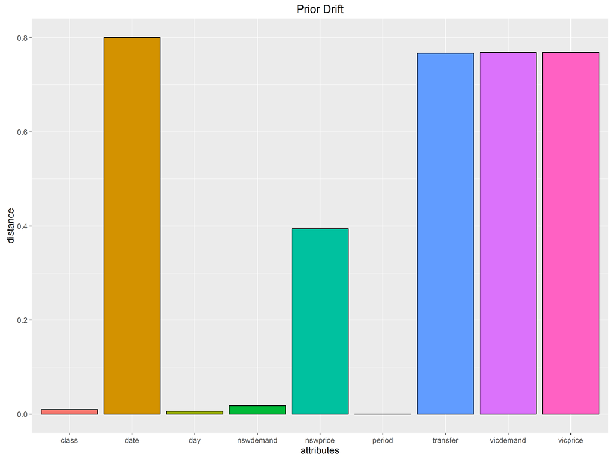

The following is the covariate results for 2 Attributes. This plot is just an exercise on how results from larger amounts of attributes might be visualised.

The plot is made by first constructing a “distance matrix” where the distance obtained for each pair of attribute is represneted.

```
##              [,1]        [,2]       [,3]       [,4]      [,5]      [,6]
##  [1,] 0.000000000 0.006311794 0.28645833 0.03094103 0.3945533 0.7673023
##  [2,] 0.006311794 0.000000000 0.09357345 0.04087218 0.8121469 0.7673023
##  [3,] 0.286458333 0.046786723 0.00000000 0.02387888 0.8282133 1.5346045
##  [4,] 0.030941031 0.081744350 0.02387888 0.00000000 0.8545198 1.5346045
##  [5,] 0.394553319 0.812146893 0.41410664 0.85451977 0.0000000 1.5346928
##  [6,] 0.767302260 0.767302260 1.53460452 0.76730226 0.7673464 0.0000000
##  [7,] 0.769023658 1.538047316 1.54113701 1.53804732 0.7690237 0.7690678
##  [8,] 1.538223870 0.769111935 0.77242232 1.53822387 1.5382239 0.7691119
##  [9,] 1.614318503 0.800847458 0.86824682 0.80111229 1.7518538 1.6630473
##            [,7]      [,8]      [,9]
##  [1,] 1.5380473 0.7691119 0.8071593
##  [2,] 0.7690237 0.7691119 0.8008475
##  [3,] 1.5411370 1.5448446 1.7364936
##  [4,] 1.5380473 0.7691119 1.6022246
##  [5,] 1.5380473 1.5382239 0.8759269
##  [6,] 0.7690678 1.5382239 1.6630473
##  [7,] 0.0000000 1.5382239 0.8477225
##  [8,] 0.7691119 0.0000000 1.6997705
##  [9,] 0.8477225 1.6997705 0.0000000
```

This matrix is then plotted using Multidimensional Scaling to visualise the distances in the matrix. The final plot will then plot attributes that have a higher dirft together further apart.

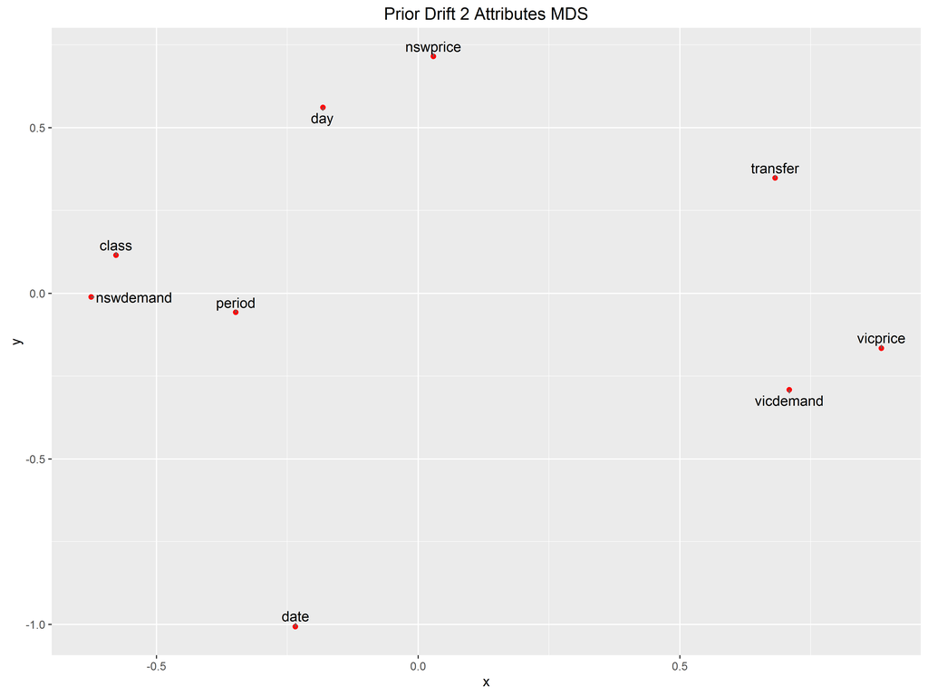

We can also plot the distance matrix as a heatmap to directly view the results. However this method only works with 2 attribute tests.

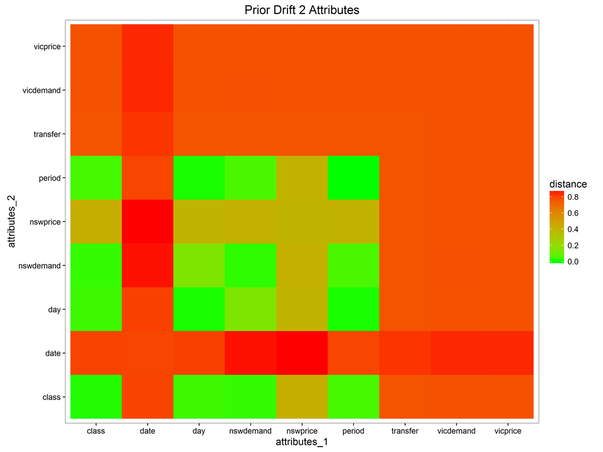

Here is a heatmap for 3 attributes that contains the attribute with the highest variance in difference.

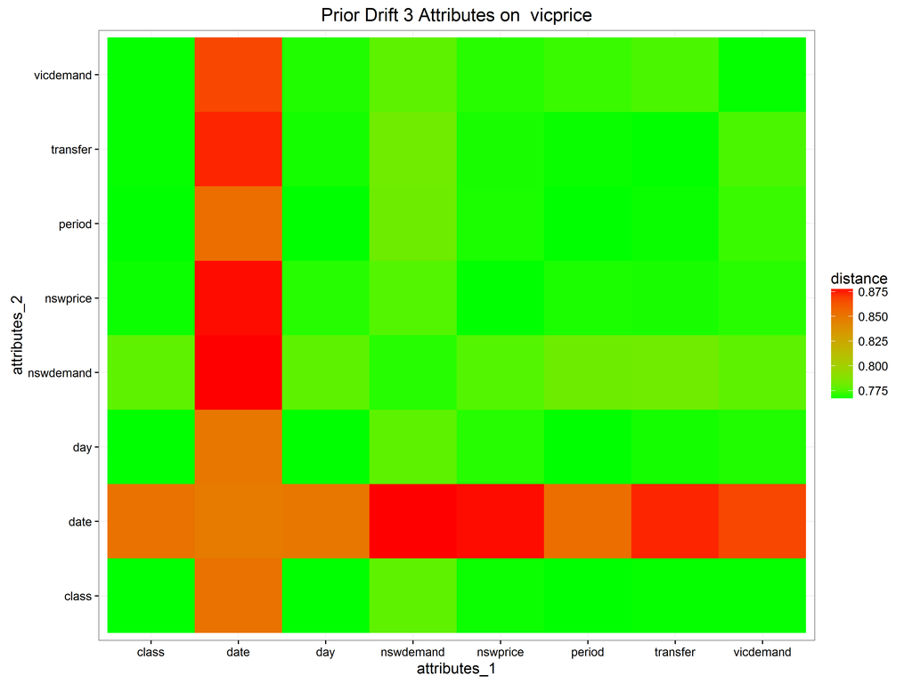

### Conditioned Covaraites (Single Attributes)

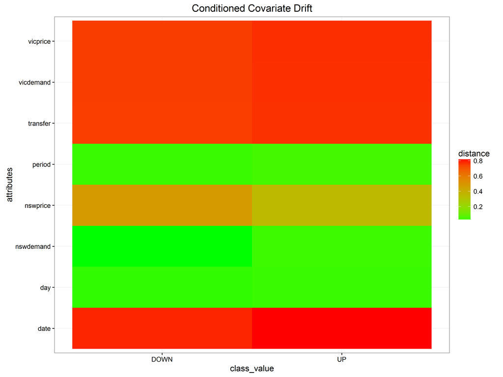

Gred Values means that the specific class does not occur in the dataset.

```
## [1] "Plots obtained"
```

[figure not shown]

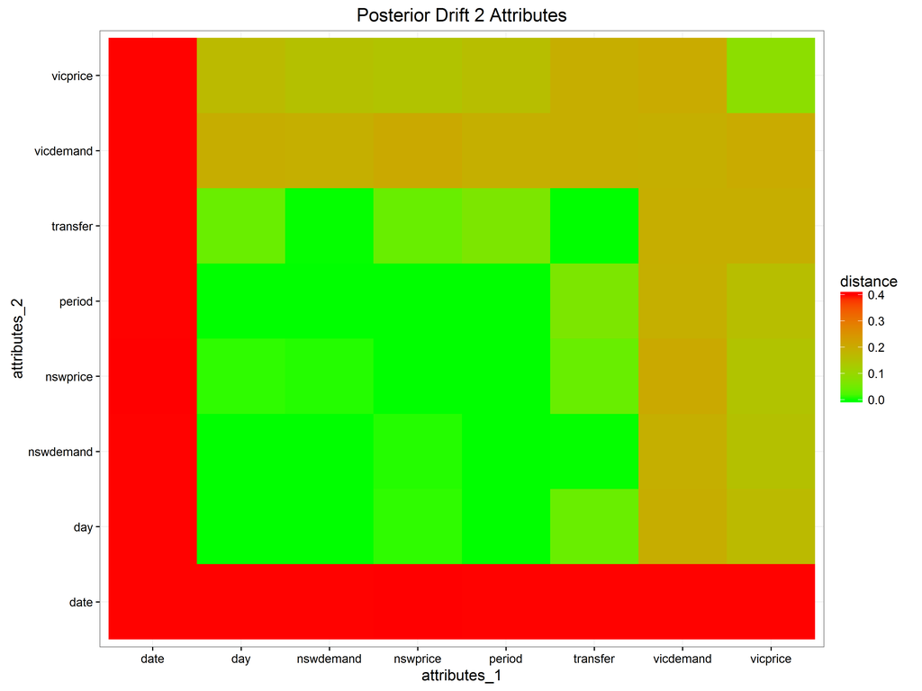

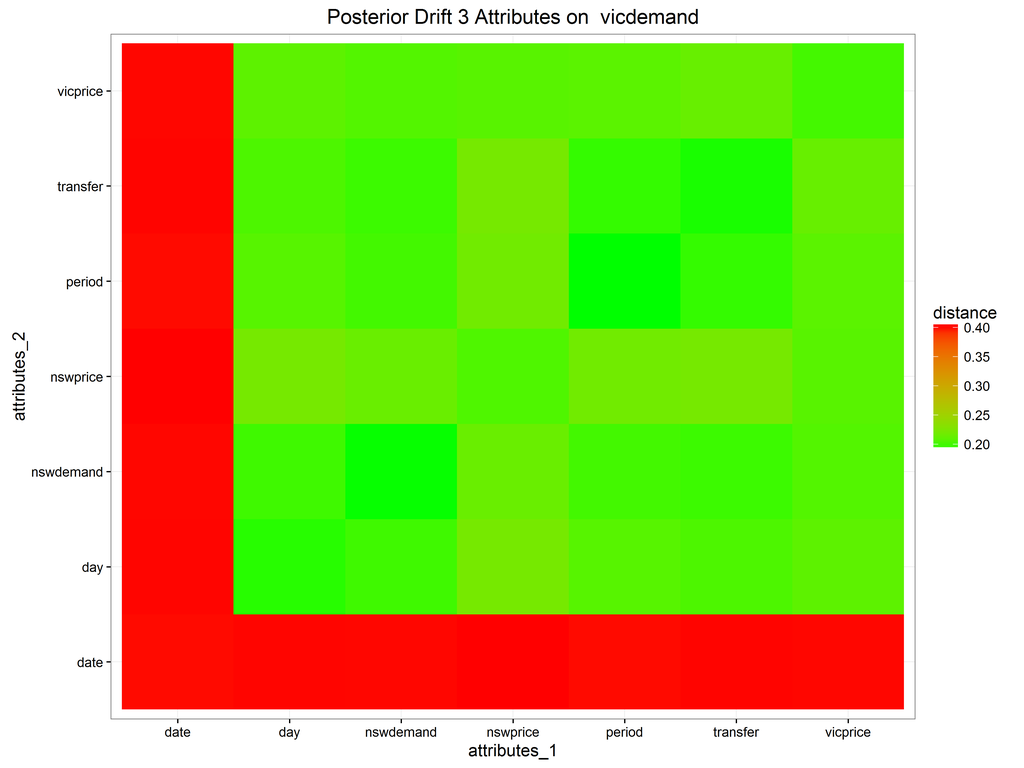

## Raw Data

https://github.com/LeeLoongKuan/DriftMapper/tree/master/data_out/martvard

## Raw Plots

https://github.com/LeeLoongKuan/DriftMapper/tree/master/DataAnalysisR/Plots